# ProblemSet 5_Aijing_Gao

Aijing Gao

November 11, 2017

## Simulation

1. Optimal Functional Forms:

LASSO, CART, GAM has different advantage in different scenario:

- LASSO perform well when predictors have strong correlation
- GAM is capable of capturing non-linearities
- CART is good for modeling heterogenity (i.e. interactions)

To compare their model performance, here I simulated three datasets:

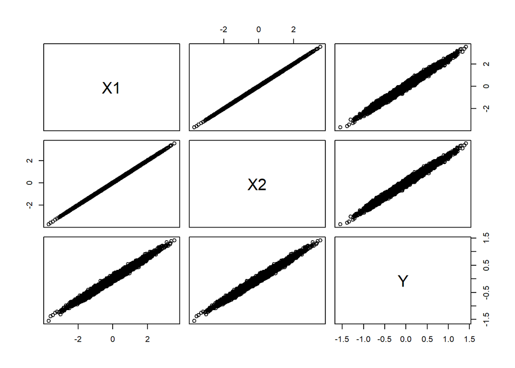

```r
##simulated dat1 with strong multicolinearity
obs = 8000
vars = 2
set.seed(20)
X1<-rnorm(obs)
X2<-X1+0.01*rnorm(obs)
dat1<-data.frame(X1, X2)
#y=X1+X2+noise
dat1$Y<-with(dat1, 0.3*X1+0.1*X2+0.05*rnorm(obs))

##simulated dat2 with mixed parametric model
set.seed(12)
t = data.frame(replicate(vars,rnorm(obs)))
#create target by hidden function
Y = with(t, X1^2 + sin(X2*pi) + 0.5 * rnorm(obs))
dat2<-data.frame(t, Y)

##simulated a categorical variable with interaction
set.seed(78)
t = data.frame(replicate(vars,rnorm(obs)))
#y=X1+X2+5*X1*X2+noise
Y = with(t, X1+X2+5*X1*X2+ 0.5 * rnorm(obs))
dat3<-data.frame(t, Y)

#relationship between X and Y
plot(dat1)
```

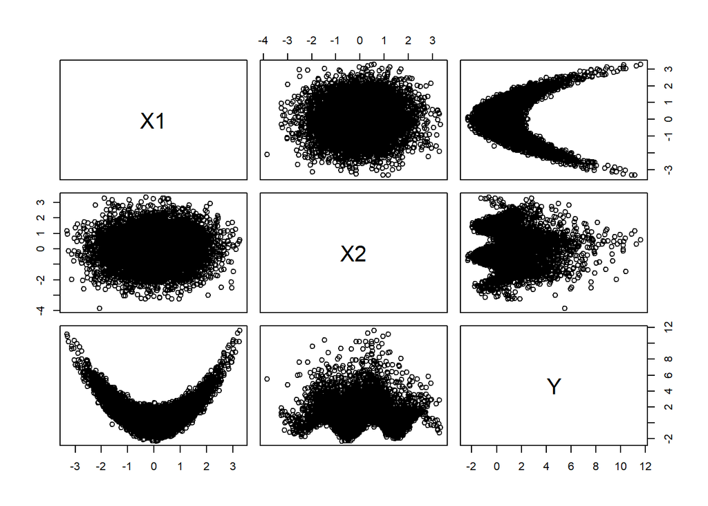

```r
plot(dat2)
```

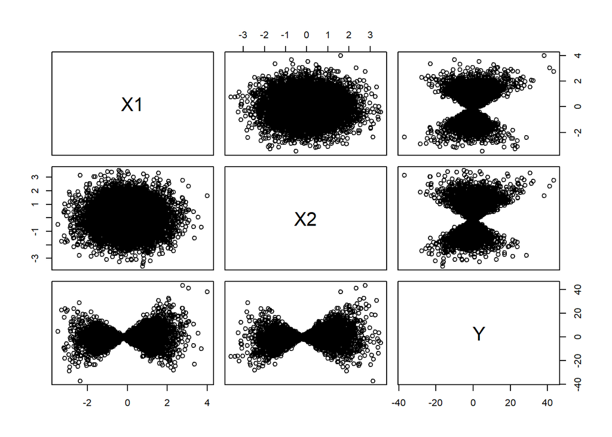

```r
plot(dat3)
```

Run LASSO, GAM, and CART independently:

```r
combine_pred<-function(dat, ratio = 0.8){
  set.seed(124)
  ind<-sample(1:nrow(dat), size=ratio*nrow(dat))
  train<-dat[ind,]
  test<-dat[-ind,]
  #LASSO
  fitLasso<-cv.glmnet(train$Y, x = as.matrix(train[,colnames(train)!="Y"]), alpha=1, family="gaussian", type.measure = "deviance")
  predLasso <- predict(fitLasso, s="lambda.min", newx = as.matrix(test[,colnames(test)!="Y"]))
  #GAM
  fitGam <- gam(Y ~ s(X1)+s(X2) , data = train)
  predGam<-predict(fitGam, test[,-3])
  #CART
  tree.cv <- rpart(Y ~ ., data = train)
  TreePred <- predict(tree.cv, newdata = test[,-3])
  mse <- function(x) mean((test$Y - x)^2)
  return(c(mse(predLasso), mse(predGam), mse(TreePred)))
}


results<-data.frame(dat1 = combine_pred(dat1), dat2 = combine_pred(dat2), dat3 = combine_pred(dat3))
results<-data.frame(t(results))
names(results)<-c("LASSO", "GAM", "CART")
htmlTable::htmlTable(txtRound(results, digits =4), caption = "Table 1. Summarized results of prediction accuracy by different learning algorithm")
```

| Table 1. Summarized results of prediction accuracy by different learning algorithm | Table 1. Summarized results of prediction accuracy by different learning algorithm LASSO | Table 1. Summarized results of prediction accuracy by different learning algorithm GAM | Table 1. Summarized results of prediction accuracy by different learning algorithm CART |
| --- | --- | --- | --- |
| dat1 | 0.0025 | 0.0025 | 0.0089 |
| dat2 | 2.9413 | 0.2494 | 0.7325 |
| dat3 | 26.0260 | 26.3493 | 5.4427 |

## Working with the data

2. Variable Selection Algorithms

Here I used 4 algorithms to deal with the mice data whose variables are highly correlated with each other. The data was scaled before applying the model selection algorithm. A level plot was created to demonstrate the beta coefficients.

Results:

Since models from Forward selection and backward selection were in very different scales with Ridge and LASSO, I included ridge and LASSO models in level plot and created coefficient plots for Forward (Left) and backward selection (Right) respectively.

```r
#get beta estimate from different techniques for model selection
#forward selection
fit <- glm(Genotype ~ 1, family = "binomial", data = dat)
sFor <- stepAIC(fit, direction = "forward", trace = F, scope =
                list(lower = ~1, upper = ~ DYRK1A_N + ITSN1_N + BDNF_N + NR1_N + NR2A_N + pAKT_N + pBRAF_N +
                                           pCAMKII_N + pCREB_N + pELK_N + pERK_N + pJNK_N + PKCA_N +
                                           pMEK_N + pNR1_N + pNR2A_N + pNR2B_N + pPKCAB_N + pRSK_N +
                                           AKT_N + BRAF_N + CAMKII_N + CREB_N + ELK_N + ERK_N + GSK3B_N +
                                           JNK_N + MEK_N + TRKA_N + RSK_N + APP_N + Bcatenin_N + SOD1_N +
                                           MTOR_N + P38_N + pMTOR_N + DSCR1_N + AMPKA_N + NR2B_N + pNUMB_N +
                                           RAPTOR_N + TIAM1_N + pP70S6_N + NUMB_N + P70S6_N + pGSK3B_N +
                                           pPKCG_N + CDK5_N + S6_N + ADARB1_N + AcetylH3K9_N + RRP1_N +
                                           BAX_N + ARC_N + ERBB4_N + nNOS_N + Tau_N + GFAP_N + GluR3_N +
                                           GluR4_N + IL1B_N + P3525_N + pCASP9_N + PSD95_N + SNCA_N +
                                           Ubiquitin_N + pGSK3B_Tyr216_N + SHH_N + pS6_N + pCFOS_N +
                                           SYP_N + CaNA_N))
t<-c(sFor$coefficients, rep(0, 35))
names(t)[39:73]<-colnames(dat[,-73])[!colnames(dat[,-73])%in%names(sFor$coefficients)]
temp<-t(as.data.frame(t))[,c("(Intercept)", colnames(dat)[1:72])]
#backward seletion
fit <- glm(Genotype ~ ., family = "binomial", data = dat)
sBack <- stepAIC(fit, trace = F, direction = "backward")
t<-c(sBack$coefficients, rep(0, 33))
names(t)[41:73]<-colnames(dat[,-73])[!colnames(dat[,-73])%in%names(sBack$coefficients)]
temp2<-t(as.data.frame(t))[,c("(Intercept)", colnames(dat)[1:72])]
#Ridge regression
fit.ridge.cv <- cv.glmnet(as.matrix(dat[,c(1:72)]), dat$Genotype, type.measure="deviance",  alpha=0, family="binomial", parallel = TRUE)
#lasso regression
fit.lasso.cv <- cv.glmnet(as.matrix(dat[,c(1:72)]), dat$Genotype, type.measure="deviance",  alpha=1, family="binomial", parallel = TRUE)
```

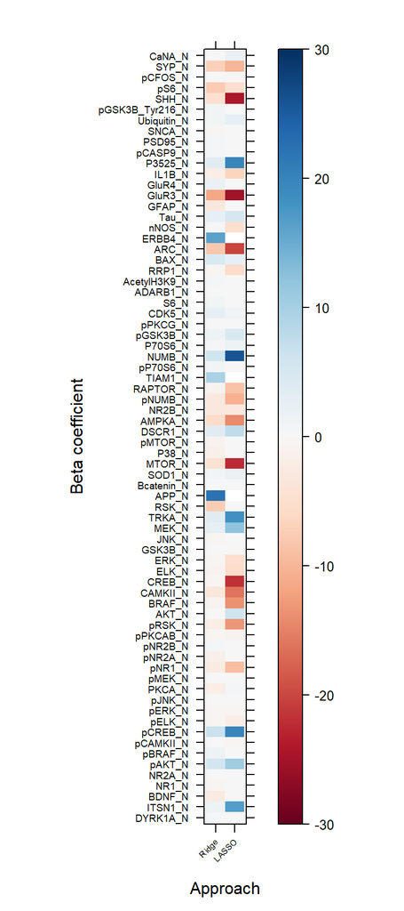

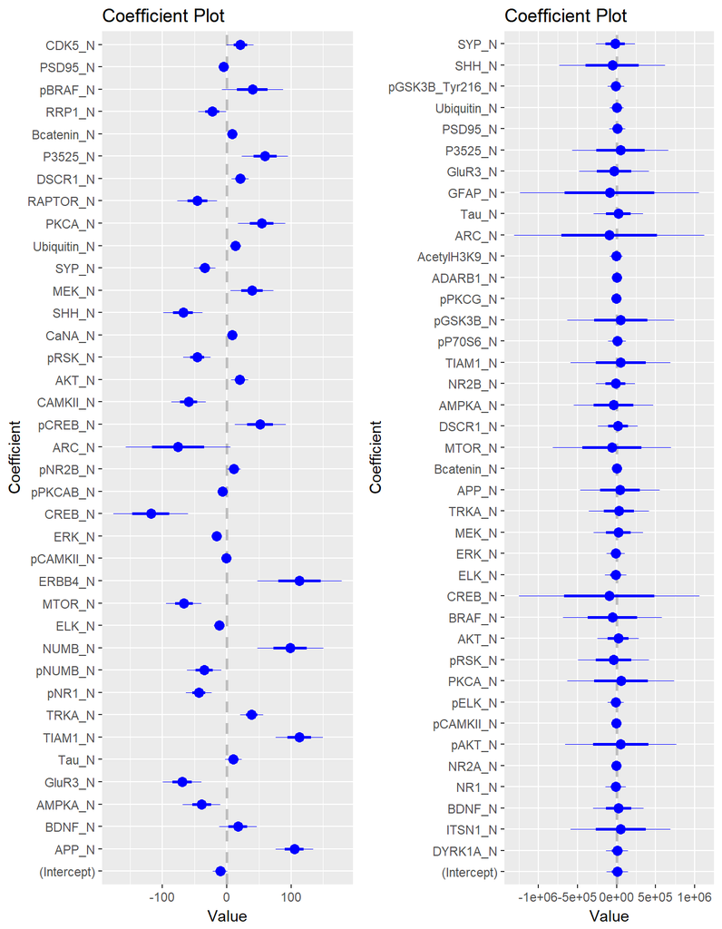

2. Use Cross-Validation to assess which approach performs best: Here 10-fold cross-validation was used to compare the 4 different models and AUC (c-statistics) was used to measure prediction accuracy.

   | Table 2. c-statistics after using different learning algorithms | Table 2. c-statistics after using different learning algorithms Forward | Table 2. c-statistics after using different learning algorithms Backward | Table 2. c-statistics after using different learning algorithms Ridge | Table 2. c-statistics after using different learning algorithms LASSO |
   | --- | --- | --- | --- | --- |
   | 1 | 0.952 | 0.946 | 0.983 | 0.994 |

As indicated by the results, I think the LASSO is best technique for model selection in dealing with this dataset.

3. Random Forest

I set up a tuning parameter grid with different mtry and nodesize respectively using functions in random forest packages

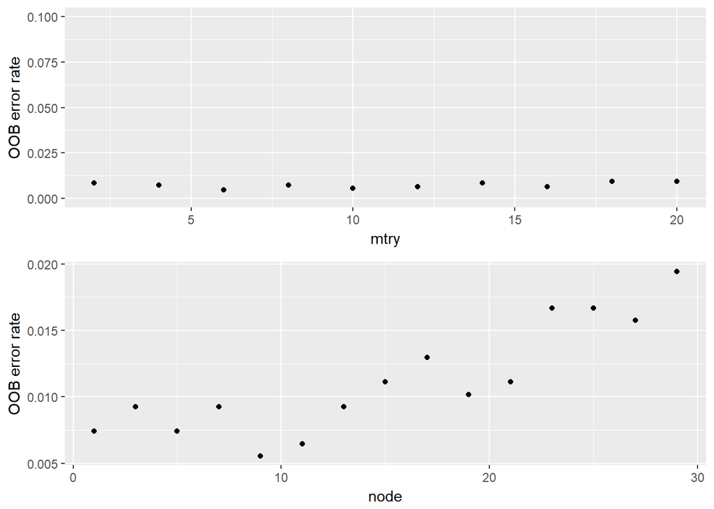

```r
#tuning by changing mtry
mtry<-seq(2, 20, by = 2)
OOB_mtry = NULL
for(i in 1:length(mtry)){
   set.seed(222)
   model <- randomForest(factor(Genotype)~., data=dat, mtry = mtry[i], importance=TRUE)
   OOB_mtry[i]<-mean( predict( model ) != dat$Genotype )
}

#tuning by changing nodesize
node<-seq(1, 30, by = 2)
OOB=NULL
for(i in 1:length(node)){
  set.seed(222)
  model <- randomForest(factor(Genotype)~., data=dat, nodesize = node[i], importance=TRUE)
  OOB[i]<-mean( predict( model ) != dat$Genotype )
}

#visualize the results
q1<-qplot(mtry, OOB_mtry)+ylab("OOB error rate")+ylim(0, 0.1)
q2<-qplot(node, OOB)+ylab("OOB error rate")
q<-multiplot(q1, q2)
```

Comments: The optimal mtry=6 and optimal nodesize = 9. Besides, I found nodesize tended to have a greater impact on OOB error rate.

4. Variable Selection

(a). Perform multiple T test

After controlling FDR as 0.1, we found 44 variables as significant variables.

```r
t_test<-function(dat, i){
  return(t.test(dat[dat$Genotype==1,i], dat[dat$Genotype==0,i])$p.value)
}

raw.pval<-unlist(lapply(1:72, function(x) t_test(dat, x)))
BH<-p.adjust(raw.pval, method = "BH")
sum(BH<=0.1)
```

```
## [1] 44
```

(b). Identify top variables:

```r
t<-names(dat)[1:72][which(BH<=0.1)]%in%names(dat)[1:72][which(LASSO[-1]!=0)]
sum(t)
```

```
## [1] 30
```

```r
names(dat[,c(1:72)])[t]
```

```
##  [1] "ITSN1_N"         "NR2A_N"          "pAKT_N"
##  [4] "pCAMKII_N"       "pCREB_N"         "pERK_N"
##  [7] "pJNK_N"          "PKCA_N"          "pMEK_N"
## [10] "pNR1_N"          "pNR2A_N"         "pNR2B_N"
## [13] "pPKCAB_N"        "pRSK_N"          "CAMKII_N"
## [16] "CREB_N"          "ELK_N"           "ERK_N"
## [19] "JNK_N"           "MEK_N"           "RSK_N"
## [22] "APP_N"           "MTOR_N"          "P38_N"
## [25] "pMTOR_N"         "DSCR1_N"         "AMPKA_N"
## [28] "NR2B_N"          "TIAM1_N"         "NUMB_N"
## [31] "pGSK3B_N"        "S6_N"            "ADARB1_N"
## [34] "RRP1_N"          "BAX_N"           "ERBB4_N"
## [37] "nNOS_N"          "Tau_N"           "GFAP_N"
## [40] "GluR3_N"         "GluR4_N"         "IL1B_N"
## [43] "P3525_N"         "pCASP9_N"        "Ubiquitin_N"
## [46] "pGSK3B_Tyr216_N" "SHH_N"           "pS6_N"
## [49] "SYP_N"           "CaNA_N"
```

All the variables were values for gene expression, which are in the same scale. Thus, it’s not necessary to scale the data ahead of time.

(c). Calculate gini and permutation importance:

```r
model <- randomForest(factor(Genotype)~., data=dat, nodesize = 9, mtry = 6, importance=TRUE)
#permutation importance
importance(model, type = 1, scale = FALSE)
```

```
##                 MeanDecreaseAccuracy
## DYRK1A_N                 0.021133408
## ITSN1_N                  0.043454807
## BDNF_N                   0.004554931
## NR1_N                    0.004716765
## NR2A_N                   0.007985260
## pAKT_N                   0.005001081
## pBRAF_N                  0.002866990
## pCAMKII_N                0.011923972
## pCREB_N                  0.009303058
## pELK_N                   0.005275046
## pERK_N                   0.010939516
## pJNK_N                   0.003188063
## PKCA_N                   0.007226637
## pMEK_N                   0.004755416
## pNR1_N                   0.005613653
## pNR2A_N                  0.007098457
## pNR2B_N                  0.003362336
## pPKCAB_N                 0.007762648
## pRSK_N                   0.003623464
## AKT_N                    0.004767475
## BRAF_N                   0.013787719
## CAMKII_N                 0.005051629
## CREB_N                   0.003333903
## ELK_N                    0.003137302
## ERK_N                    0.005882209
## GSK3B_N                  0.006876160
## JNK_N                    0.003932217
## MEK_N                    0.003016187
## TRKA_N                   0.004380518
## RSK_N                    0.003220497
## APP_N                    0.072108331
## Bcatenin_N               0.002862540
## SOD1_N                   0.016321923
## MTOR_N                   0.010388853
## P38_N                    0.012406119
## pMTOR_N                  0.014057833
## DSCR1_N                  0.010591328
## AMPKA_N                  0.015996429
## NR2B_N                   0.010937485
```

[output cut: 18 more lines]

```
## GFAP_N                   0.003667135
## GluR3_N                  0.012487668
## GluR4_N                  0.003688960
## IL1B_N                   0.004817934
## P3525_N                  0.002719271
## pCASP9_N                 0.003941525
## PSD95_N                  0.005182275
## SNCA_N                   0.001945676
## Ubiquitin_N              0.008496711
## pGSK3B_Tyr216_N          0.004180878
## SHH_N                    0.002406579
## pS6_N                    0.011378781
## pCFOS_N                  0.001902941
## SYP_N                    0.015081667
## CaNA_N                   0.008159814
```

```r
#gini importance
importance(model, type = 2, scale = FALSE)
```

```
##                 MeanDecreaseGini
## DYRK1A_N               10.364569
## ITSN1_N                24.075341
## BDNF_N                  3.706606
## NR1_N                   4.271583
## NR2A_N                  6.779292
## pAKT_N                  4.159323
## pBRAF_N                 2.619115
## pCAMKII_N               8.265052
## pCREB_N                 6.582936
## pELK_N                  4.737039
## pERK_N                  7.086398
## pJNK_N                  2.758262
## PKCA_N                  5.159031
## pMEK_N                  3.755492
## pNR1_N                  5.311964
## pNR2A_N                 5.990712
## pNR2B_N                 3.084368
## pPKCAB_N                6.154756
## pRSK_N                  3.383467
## AKT_N                   3.218700
## BRAF_N                  7.794149
## CAMKII_N                4.051712
## CREB_N                  3.675489
## ELK_N                   3.564447
## ERK_N                   4.670658
## GSK3B_N                 6.078856
## JNK_N                   3.648206
## MEK_N                   2.359292
## TRKA_N                  3.736106
## RSK_N                   2.735552
## APP_N                  53.324685
## Bcatenin_N              2.814577
## SOD1_N                 10.293711
## MTOR_N                  7.211558
## P38_N                   9.694511
## pMTOR_N                10.143832
## DSCR1_N                 7.346113
## AMPKA_N                10.984789
## NR2B_N                  7.866135
```

[output cut: 18 more lines]

```
## GFAP_N                  4.181789
## GluR3_N                 8.880447
## GluR4_N                 3.847364
## IL1B_N                  4.609616
## P3525_N                 3.510941
## pCASP9_N                3.293752
## PSD95_N                 5.060308
## SNCA_N                  2.204384
## Ubiquitin_N             6.808645
## pGSK3B_Tyr216_N         4.061868
## SHH_N                   2.798332
## pS6_N                   6.732736
## pCFOS_N                 2.293298
## SYP_N                   7.819059
## CaNA_N                  6.593352
```

(d). Compare importance of variables from different procedures: I compared absolute value of beta coefficients from LASSO, ordering of p-value from MTP, permutation importance, and gini importance from random forest. As indicated by the results (Table 3), different procedure have different results on variable importance.

```r
names(LASSO)<-c("Intercept",names(dat)[1:72])
imp<-data.frame(LASSO0 = names(LASSO[-1])[order(abs(LASSO[-1]), decreasing = TRUE)],
                MTP = names(dat)[1:72][order(BH)],
                RF = names(dat)[1:72][order(importance(model, type = 1, scale = FALSE), decreasing = TRUE)],
                Gini = names(dat)[1:72][order(importance(model, type = 2, scale = FALSE), decreasing = TRUE)])
colnames(imp)<-c("LASSO", "MTP", "Permutation Importance","Gini Importance")
htmlTable::htmlTable(imp[1:10,], caption = "Table 3. Variable importance from different procedures")
```

| Table 3. Variable importance from different procedures | Table 3. Variable importance from different procedures LASSO | Table 3. Variable importance from different procedures MTP | Table 3. Variable importance from different procedures Permutation Importance | Table 3. Variable importance from different procedures Gini Importance |
| --- | --- | --- | --- | --- |
| 1 | ERBB4_N | APP_N | APP_N | APP_N |
| 2 | APP_N | S6_N | ITSN1_N | ITSN1_N |
| 3 | TIAM1_N | pPKCG_N | AcetylH3K9_N | Tau_N |
| 4 | NUMB_N | Tau_N | Tau_N | AcetylH3K9_N |
| 5 | GluR3_N | GluR3_N | DYRK1A_N | pPKCG_N |
| 6 | SHH_N | AcetylH3K9_N | S6_N | S6_N |
| 7 | MTOR_N | pNR2A_N | pPKCG_N | AMPKA_N |
| 8 | CREB_N | SYP_N | SOD1_N | DYRK1A_N |
| 9 | ARC_N | MTOR_N | AMPKA_N | SOD1_N |
| 10 | pCREB_N | AMPKA_N | SYP_N | pMTOR_N |

5. Stacking (a). I plan to use random forest and LASSO logistic regression from glmnet.

(b). Apply CV.SuperLearner() to apply cross-validation. The SuperLearner error rate represents the proportion of misclassification over the entire data. In this problem, risk (performance metrics) was measured based on mean squared error.

```r
# Set the seed for reproducibility.
set.seed(123)
sl = CV.SuperLearner(Y = dat$Genotype, X = dat[,c(1:72)], family = binomial(),
                     SL.library = c("SL.glmnet", "SL.randomForest"), parallel = "multicore")
summary(sl)
```

```
##
## Call:
## CV.SuperLearner(Y = dat$Genotype, X = dat[, c(1:72)], family = binomial(),
##     SL.library = c("SL.glmnet", "SL.randomForest"), parallel = "multicore")
##
##
## Risk is based on: Mean Squared Error
##
## All risk estimates are based on V =  10
##
##            Algorithm      Ave        se       Min      Max
##        Super Learner 0.020062 0.0018280 0.0109536 0.034650
##          Discrete SL 0.022748 0.0031800 0.0079959 0.043195
##        SL.glmnet_All 0.022748 0.0031800 0.0079959 0.043195
##  SL.randomForest_All 0.031595 0.0013884 0.0262117 0.042824
```

```r
sl$coef
```

```
##    SL.glmnet_All SL.randomForest_All
## 1      0.5331588           0.4668412
## 2      0.4598756           0.5401244
## 3      0.5354015           0.4645985
## 4      0.5368207           0.4631793
## 5      0.5329475           0.4670525
## 6      0.5242695           0.4757305
## 7      0.6210807           0.3789193
## 8      0.5876993           0.4123007
## 9      0.5257981           0.4742019
## 10     0.5251055           0.4748945
```

(c). According to the coefficients (weights) and risk by the two models, we could conclude the LASSO regression outperformed than random forest. The mean squared error for LASSO is 0.0227 and for random forest is 0.0316. The error rate for super learner is 0.02.

(d). Find the running time:

```r
# Review how long it took to run the SuperLearner:
system.time(sl <- CV.SuperLearner(Y = dat$Genotype, X = dat[,c(1:72)], family = binomial(),
                     SL.library = c("SL.glmnet", "SL.randomForest"), parallel = "multicore"))
```

```
##    user  system elapsed
## 1511.80    2.94 1520.60
```

It takes a long time to run superleaner. However, I found the risk was not significantly reduced after stacking the two algorithms compared to using LASSO regression alone. It may be not very valueable to do stacking since LASSO could already give pretty good prediction.

6. Developing A prediction model:

(b). Data imputation:

- remove variables with more than 10% missing values
- perform mean imputation on the variables that have less than 10% missing values

(c). From the results of questions in this homework, I think LASSO regression is the best model. Thus, a LASSO regression was fit

(d). Mean squared loss was used to measure the accuracy of the prediction model. From the output of R, I found the MSE is 0.02027.

Detailed code and Rdata was seen in the attachment (Aijing_Gao_PS5_Q6.R and MouseData.RData).